# Exercises - GEO4902-01 - General modeling concepts

[Save google-collab as jupyter notebook, with your name in the filename, and upload on canvas]

# Exercise 01B - Access and plot AROME MetCoOp and ECMWF IFS forecasts

## Example for an extreme precipitation event in October 2014 in West Norway

```python
import xarray as xr
import numpy as np
from matplotlib import pyplot as plt
import cartopy as cy
from cmcrameri import cm
```

##### Specifiy input fields: AROME MetCoOp and ECMWF IFS forecasts

```python
day='26'; month='10'; year='2014'; HH='12'

url='https://thredds.met.no/thredds/dodsC/aromemetcoopstarc/'+str(year)+'/'+str(month)+'/'+str(day)+'/AROME_MetCoOp_'+str(HH)+'_fp.nc_'+str(year)+str(month)+str(day)
arome = xr.open_dataset(url)

url='https://thredds.met.no/thredds/dodsC/metusers/maltem/GEO4902_2020/Arctic.ECMWF_extracted_'+str(year)+str(month)+str(day)+'T'+str(HH)+'Z.nc'
ecifs =  xr.open_dataset(url)
```

### Find a specific point and plot the forecast.

###### Note AROME MetCoOp is on an irregular grid, so the xarray.sel functionality does not work. But it does work for the ECMWF IFS grid (see below)

```python
def findindex(alat,alon,plat,plon):
    #finding identical location of pos plat, plon in array alat[],alon[]
    abslat = np.abs(alat-plat)
    abslon = np.abs(alon-plon)
    c = np.maximum(abslon,abslat)
    y, x = np.where(c == np.min(c))
    #print(alats[x,y],alon[x,y])
    y=int(y[0])
    x=int(x[0])
    return (y,x)
```

```python
lat0=60.8608; lon0=7.1118 # Flåm in Western Norway

[yloc,xloc] = findindex(arome.latitude,arome.longitude,lat0,lon0) # from regional model AROME MetCoOp

print(float(arome.latitude[yloc,xloc]))
print(float(arome.longitude[yloc,xloc]))
```

```
60.85884915703827
7.091471930071294
```

### The ECMWF IFS precipitation is subdivided into large scale or stratiform precipitation (LSP) and convective precipitation (TP-LSP)

```python
ecifs
```

```
<xarray.Dataset> Size: 396MB
Dimensions:  (time: 67, lon: 961, lat: 256)
Coordinates:
  * time     (time) datetime64[ns] 536B 2014-10-26T12:00:00 ... 2014-10-29T06...
  * lon      (lon) float64 8kB -60.0 -59.88 -59.75 -59.62 ... 59.75 59.88 60.0
  * lat      (lat) float64 2kB 57.06 57.19 57.31 57.44 ... 88.69 88.81 88.94
Data variables:
    SP       (time, lat, lon) float32 66MB ...
    U10M     (time, lat, lon) float32 66MB ...
    V10M     (time, lat, lon) float32 66MB ...
    T2M      (time, lat, lon) float32 66MB ...
    TP       (time, lat, lon) float32 66MB ...
    LSP      (time, lat, lon) float32 66MB ...
Attributes:
    CDI:                             Climate Data Interface version 1.9.8 (ht...
    Conventions:                     CF-1.6
    history:                         Tue Jun 30 14:30:09 2020: cdo -sellonlat...
    institution:                     European Centre for Medium-Range Weather...
    CDO:                             Climate Data Operators version 1.9.8 (ht...
    DODS_EXTRA.Unlimited_Dimension:  time
```

```python
pp_acc_point_arome = arome.precipitation_amount_acc.isel(height0=0,y=yloc,x=xloc)
pp_acc_point_ecifs = ecifs.sel(lat=lat0,lon=lon0,method='nearest')
```

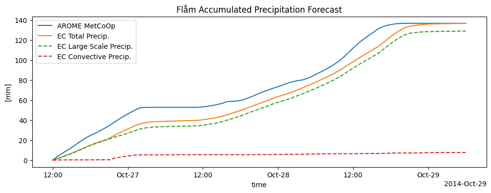

```python
plt.figure(figsize=(12,4))
pp_acc_point_arome.plot(x='time', linestyle='-', label='AROME MetCoOp')
(pp_acc_point_ecifs.TP*1000).plot(x='time', linestyle='-',label='EC Total Precip.')
(pp_acc_point_ecifs.LSP*1000).plot(x='time', linestyle='--',label='EC Large Scale Precip.')
((pp_acc_point_ecifs.TP-pp_acc_point_ecifs.LSP)*1000).plot(x='time',linestyle='--',label='EC Convective Precip.')

plt.legend()
plt.ylabel('[mm]')
plt.title("Flåm Accumulated Precipitation Forecast")
plt.show()
```

### Plot the two accumulated precipitation forecasts on a map

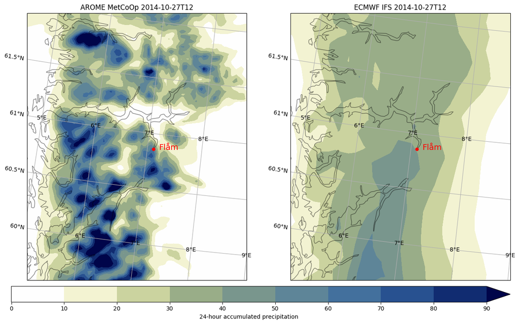

```python
timestep=24 # 24-hour accumulated precipitation
levelsPP = range(0,100,10)


projection = cy.crs.LambertConformal(central_longitude =arome.projection_lambert.longitude_of_central_meridian,
                                       central_latitude  =arome.projection_lambert.latitude_of_projection_origin,
                                       standard_parallels = arome.projection_lambert.standard_parallel)
f, axsm = plt.subplots(1,2, subplot_kw={'projection' : projection}, figsize=(15.2,15.5), sharex=True, sharey=True)

for ax in axsm.flatten():
    ax.set_extent([lon0-2, lon0+1.5, lat0-1.1, lat0+1.1], cy.crs.PlateCarree())
    ax.add_feature(cy.feature.COASTLINE, alpha=0.5)
    ax.add_feature(cy.feature.BORDERS, alpha=0.5)
    gl = ax.gridlines(draw_labels=True)
    gl.top_labels   = False
    gl.right_labels = False

    ax.plot(lon0, lat0, 'ro', markersize=5, transform=cy.crs.PlateCarree())
    ax.text(lon0 + 0.1, lat0, 'Flåm', fontsize=14, color='red', transform=cy.crs.PlateCarree())

arome.precipitation_amount_acc.isel(time=timestep,height0=0).plot.contourf(ax=axsm[0], transform=projection, cmap=cm.davos_r, extend='max',levels=levelsPP,add_colorbar=False)
axsm[0].set_title('AROME MetCoOp '+np.datetime_as_string(arome.time[timestep],unit='h'))

cf = (ecifs.TP.isel(time=timestep)*1000).plot.contourf(ax=axsm[1], transform=cy.crs.PlateCarree(), cmap=cm.davos_r, extend='max', levels=levelsPP, add_colorbar=False)
axsm[1].set_title ('ECMWF IFS '+np.datetime_as_string(arome.time[timestep],unit='h'))

cbaxes = f.add_axes([0.1, 0.25, 0.8, 0.025])
cbar = plt.colorbar(cf, cax=cbaxes, shrink=0.5, orientation='horizontal', extend='max',label='24-hour accumulated precipitation')
```

[figure not shown]

For the Flåm forecast we see that AROME predicts more precipitation leading into the 27th of October. From then on the AROME and EC total precipitation rate is fairly similar unit the Arome rate increases a little and then stops before EC total.

On the map plot we can see that the models have a different resolution, AROME is able to resolve smaller and more intense precipitation features whilst the ECMWF model shows a larger smoothed system.

The main reason is likely the difference in model resolution and thus implementation of convective precipitation. The AROME model with it's 2.5km resolution is able to resolve many convective processes. ECMWF IFS had a resolution of 18km (now 9km since 2023) at the time and therefore relies much more heavily on parametrization schemes for convective precipitation.

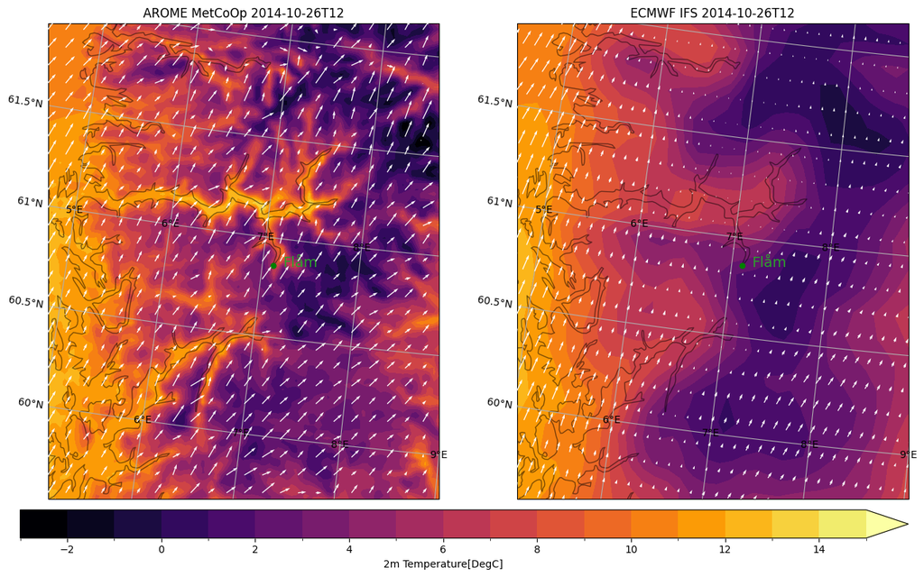

```python
Trange = range(-3,16,1)


projection = cy.crs.LambertConformal(central_longitude =arome.projection_lambert.longitude_of_central_meridian,
                                       central_latitude  =arome.projection_lambert.latitude_of_projection_origin,
                                       standard_parallels = arome.projection_lambert.standard_parallel)
f, axsm = plt.subplots(1,2, subplot_kw={'projection' : projection}, figsize=(15.2,15.5), sharex=True, sharey=True)

for ax in axsm.flatten():
    ax.set_extent([lon0-2, lon0+1.5, lat0-1.1, lat0+1.1], cy.crs.PlateCarree())
    ax.add_feature(cy.feature.COASTLINE, alpha=0.5)
    ax.add_feature(cy.feature.BORDERS, alpha=0.5)
    gl = ax.gridlines(draw_labels=True)
    gl.top_labels   = False
    gl.right_labels = False

    ax.plot(lon0, lat0, 'go', markersize=5, transform=cy.crs.PlateCarree())
    ax.text(lon0 + 0.1, lat0, 'Flåm', fontsize=14, color='tab:green', transform=cy.crs.PlateCarree())

arome_temp_C = arome.air_temperature_2m.isel(time=0,height1=0) -273.15
arome_temp_C.plot.contourf(ax=axsm[0], transform=projection, cmap='inferno', extend='max',levels=Trange,add_colorbar=False)
axsm[0].set_title('AROME MetCoOp '+np.datetime_as_string(arome.time[0],unit='h'))

cf = (ecifs.T2M.isel(time=0)-273.15).plot.contourf(ax=axsm[1], transform=cy.crs.PlateCarree(), cmap='inferno', extend='max', levels=Trange, add_colorbar=False)
axsm[1].set_title ('ECMWF IFS '+np.datetime_as_string(arome.time[0],unit='h'))

cbaxes = f.add_axes([0.1, 0.25, 0.8, 0.025])
cbar = plt.colorbar(cf, cax=cbaxes, shrink=0.5, orientation='horizontal', extend='max',label='2m Temperature[DegC]')

# Add wind
u_arome = arome.x_wind_10m.isel(time=0, height2=0)
v_arome = arome.y_wind_10m.isel(time=0, height2=0)

u_arome = u_arome.values
v_arome = v_arome.values
lat_arome = arome.latitude.values
lon_arome = arome.longitude.values

step=4
axsm[0].quiver(lon_arome[::step, ::step],
        lat_arome[::step, ::step],
        u_arome[::step, ::step],
        v_arome[::step, ::step],
        transform=cy.crs.PlateCarree(), scale=400, zorder=3, color='white')

u_ecifs = ecifs.U10M.isel(time=0)
v_ecifs = ecifs.V10M.isel(time=0)

u_ecifs = u_ecifs.values
v_ecifs = v_ecifs.values
lat_ecifs_1d = ecifs.lat.values
lon_ecifs_1d = ecifs.lon.values
lat_ecifs, lon_ecifs = np.meshgrid(lat_ecifs_1d, lon_ecifs_1d, indexing='ij')

step=1
axsm[1].quiver(lon_ecifs[::step, ::step],
        lat_ecifs[::step, ::step],
        u_ecifs[::step, ::step],
        v_ecifs[::step, ::step],
        transform=cy.crs.PlateCarree(), scale=400, zorder=3, color='white')
```

[figure not shown]

The 2m temperature with the 10m wind overlaid is shown in the figure above. Here we see that the two models agree relatively well for both variables, but again the spatial resolution is much higher in AROME. The general wind direction is fairly similar, but there are some differences in magnitude. It should also be noted that for wind, all grid points a plotted for ECMWF IFS whils only every 4th point is plotted for AROME. AROME shows much stronger winds around Flåm compared to ECMWF IFS. AROMEs grid followes the local topography and may therefore resolve local topographic steering of the wind. These local effects may be lost in the ECMWF model due to it's coarser resolution. ECMFWF IFS also uses a Gaussian grid, but I don't think this matters in this case.

# Polar Low Febuary 4, 2020

```python
day='04'; month='02'; year='2020'; HH='00'

url='https://thredds.met.no/thredds/dodsC/aromemetcoopstarc/'+str(year)+'/'+str(month)+'/'+str(day)+'/AROME_MetCoOp_'+str(HH)+'_fp.nc_'+str(year)+str(month)+str(day)

working_url = 'https://thredds.met.no/thredds/dodsC/mepsoldarchive/2020/02/04/meps_mbr1_full_2_5km_20200204T00Z.nc'
arome = xr.open_dataset(working_url)

url='https://thredds.met.no/thredds/dodsC/metusers/maltem/GEO4902_2020/Arctic.ECMWF_extracted_'+str(year)+str(month)+str(day)+'T'+str(HH)+'Z.nc'
ecifs =  xr.open_dataset(url)
```

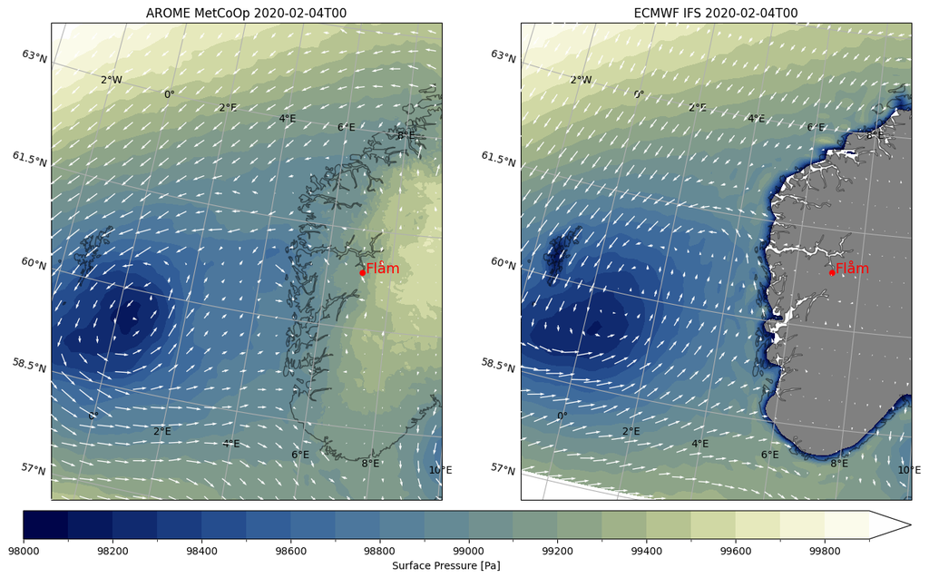

```python
Prange = range(98000, 100000, 100)

projection = cy.crs.LambertConformal(central_longitude =arome.projection_lambert.longitude_of_central_meridian,
                                       central_latitude  =arome.projection_lambert.latitude_of_projection_origin,
                                       standard_parallels = arome.projection_lambert.standard_parallel)
f, axsm = plt.subplots(1,2, subplot_kw={'projection' : projection}, figsize=(15.2,15.5), sharex=True, sharey=True)

for ax in axsm.flatten():
    ax.set_extent([-1, 9, 57.5, 64], cy.crs.PlateCarree())
    ax.add_feature(cy.feature.COASTLINE, alpha=0.5)
    ax.add_feature(cy.feature.BORDERS, alpha=0.5)
    gl = ax.gridlines(draw_labels=True)
    gl.top_labels   = False
    gl.right_labels = False

    ax.plot(lon0, lat0, 'ro', markersize=5, transform=cy.crs.PlateCarree())
    ax.text(lon0 + 0.1, lat0, 'Flåm', fontsize=14, color='red', transform=cy.crs.PlateCarree())

arome_temp_C = arome.air_pressure_at_sea_level.isel(time=0,height_above_msl=0) -273.15
arome_temp_C.plot.contourf(ax=axsm[0], transform=projection, cmap=cm.davos, extend='max',levels=Prange,add_colorbar=False)
axsm[0].set_title('AROME MetCoOp '+np.datetime_as_string(arome.time[0],unit='h'))

cf = (ecifs.SP.isel(time=0)-273.15).plot.contourf(ax=axsm[1], transform=cy.crs.PlateCarree(), cmap=cm.davos, extend='max', levels=Prange, add_colorbar=False)
axsm[1].set_title ('ECMWF IFS '+np.datetime_as_string(arome.time[0],unit='h'))

axsm[1].add_feature(cy.feature.LAND, facecolor='gray')

cbaxes = f.add_axes([0.1, 0.25, 0.8, 0.025])
cbar = plt.colorbar(cf, cax=cbaxes, shrink=0.5, orientation='horizontal', extend='max',label='Surface Pressure [Pa]')

# Add wind
u_arome = arome.x_wind_10m.isel(time=0, height7=0)
v_arome = arome.y_wind_10m.isel(time=0, height7=0)

u_arome = u_arome.values
v_arome = v_arome.values
lat_arome = arome.latitude.values
lon_arome = arome.longitude.values

step=12
axsm[0].quiver(lon_arome[::step, ::step],
        lat_arome[::step, ::step],
        u_arome[::step, ::step],
        v_arome[::step, ::step],
        transform=cy.crs.PlateCarree(), scale=400, zorder=3, color='white')

u_ecifs = ecifs.U10M.isel(time=0)
v_ecifs = ecifs.V10M.isel(time=0)

u_ecifs = u_ecifs.values
v_ecifs = v_ecifs.values
lat_ecifs_1d = ecifs.lat.values
lon_ecifs_1d = ecifs.lon.values
lat_ecifs, lon_ecifs = np.meshgrid(lat_ecifs_1d, lon_ecifs_1d, indexing='ij')

step=3
axsm[1].quiver(lon_ecifs[::step, ::step],
        lat_ecifs[::step, ::step],
        u_ecifs[::step, ::step],
        v_ecifs[::step, ::step],
        transform=cy.crs.PlateCarree(), scale=400, zorder=3, color='white')
plt.show()
```

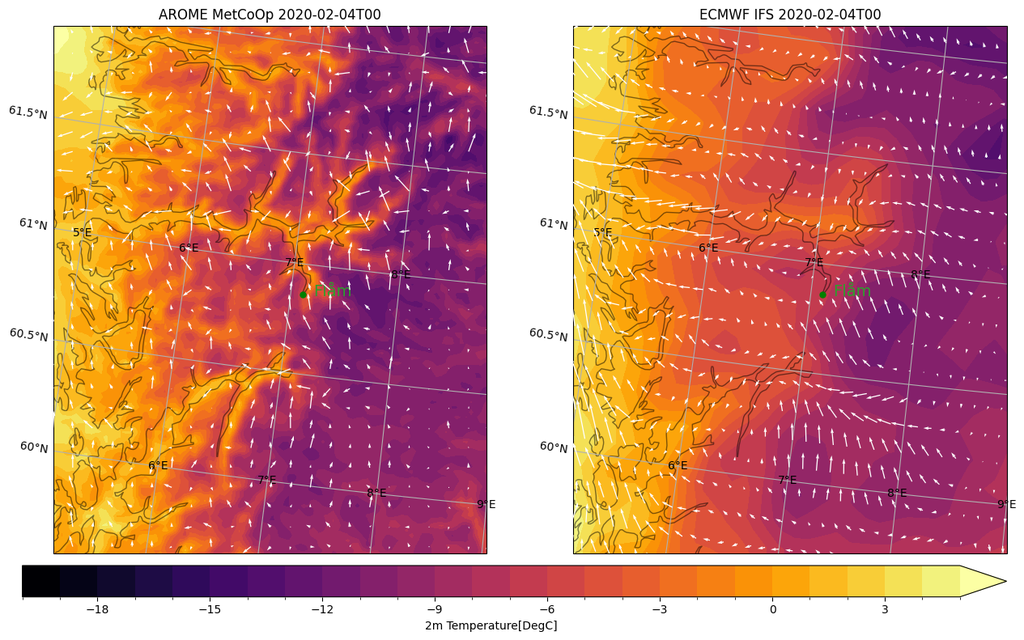

```python
Trange = range(-20,6,1)


projection = cy.crs.LambertConformal(central_longitude =arome.projection_lambert.longitude_of_central_meridian,
                                       central_latitude  =arome.projection_lambert.latitude_of_projection_origin,
                                       standard_parallels = arome.projection_lambert.standard_parallel)
f, axsm = plt.subplots(1,2, subplot_kw={'projection' : projection}, figsize=(15.2,15.5), sharex=True, sharey=True)

for ax in axsm.flatten():
    ax.set_extent([lon0-2, lon0+1.5, lat0-1.1, lat0+1.1], cy.crs.PlateCarree())
    ax.add_feature(cy.feature.COASTLINE, alpha=0.5)
    ax.add_feature(cy.feature.BORDERS, alpha=0.5)
    gl = ax.gridlines(draw_labels=True)
    gl.top_labels   = False
    gl.right_labels = False

    ax.plot(lon0, lat0, 'go', markersize=5, transform=cy.crs.PlateCarree())
    ax.text(lon0 + 0.1, lat0, 'Flåm', fontsize=14, color='tab:green', transform=cy.crs.PlateCarree())

arome_temp_C = arome.air_temperature_2m.isel(time=0,height1=0) -273.15
arome_temp_C.plot.contourf(ax=axsm[0], transform=projection, cmap='inferno', extend='max',levels=Trange,add_colorbar=False)
axsm[0].set_title('AROME MetCoOp '+np.datetime_as_string(arome.time[0],unit='h'))

cf = (ecifs.T2M.isel(time=0)-273.15).plot.contourf(ax=axsm[1], transform=cy.crs.PlateCarree(), cmap='inferno', extend='max', levels=Trange, add_colorbar=False)
axsm[1].set_title ('ECMWF IFS '+np.datetime_as_string(arome.time[0],unit='h'))

cbaxes = f.add_axes([0.1, 0.25, 0.8, 0.025])
cbar = plt.colorbar(cf, cax=cbaxes, shrink=0.5, orientation='horizontal', extend='max',label='2m Temperature[DegC]')

# Add wind
u_arome = arome.x_wind_10m.isel(time=0, height7=0)
v_arome = arome.y_wind_10m.isel(time=0, height7=0)

u_arome = u_arome.values
v_arome = v_arome.values
lat_arome = arome.latitude.values
lon_arome = arome.longitude.values

step=4
axsm[0].quiver(lon_arome[::step, ::step],
        lat_arome[::step, ::step],
        u_arome[::step, ::step],
        v_arome[::step, ::step],
        transform=cy.crs.PlateCarree(), scale=200, zorder=3, color='white')

u_ecifs = ecifs.U10M.isel(time=0)
v_ecifs = ecifs.V10M.isel(time=0)

u_ecifs = u_ecifs.values
v_ecifs = v_ecifs.values
lat_ecifs_1d = ecifs.lat.values
lon_ecifs_1d = ecifs.lon.values
lat_ecifs, lon_ecifs = np.meshgrid(lat_ecifs_1d, lon_ecifs_1d, indexing='ij')

step=1
axsm[1].quiver(lon_ecifs[::step, ::step],
        lat_ecifs[::step, ::step],
        u_ecifs[::step, ::step],
        v_ecifs[::step, ::step],
        transform=cy.crs.PlateCarree(), scale=100, zorder=3, color='white')
```

It is important to note that the wind vectors are scaled differently from previous figures and now also differently from each other. AROME shows much larger spatial variability in both wind magnitude and direction compared to ECMWF IFS. This is presumably due to a higher resolution of topography.

In the figure below we see a point forecast of the wind magnitude in Flåm during this polar low event. Here we also note much larger fluctuations for AROME, including some spikes that do not appear in the ECMWF IFS model.

Below this, the accumulated precipitation forecast shows that the two models forecast the precipitation on the 4th into the 5th. This good agreement could indicate that this was stratiform precipitation. The precipitation amount going into the 6th is forecast to be greater by AROME. This difference may be due to the ECMWF IFS convective parametrization not forecasting any precipitation.

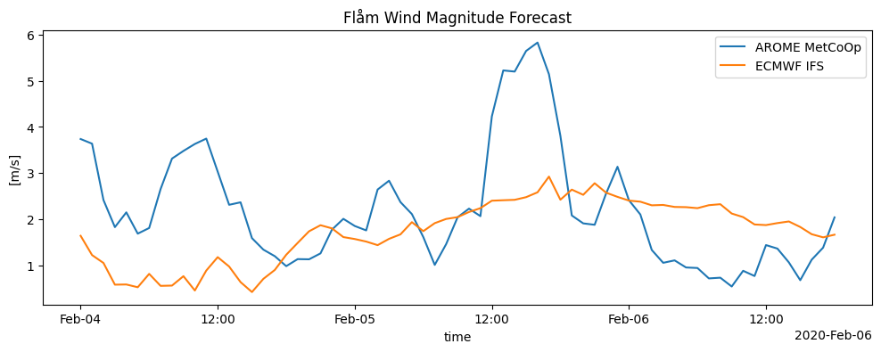

```python
plt.figure(figsize=(12,4))
u_wind_point_arome = arome.x_wind_10m.isel(height7=0,y=yloc,x=xloc)
v_wind_point_arome = arome.y_wind_10m.isel(height7=0,y=yloc,x=xloc)
wind_point_arome = np.sqrt(u_wind_point_arome**2 + v_wind_point_arome**2)

point_ecifs = ecifs.sel(lat=lat0,lon=lon0,method='nearest')
wind_point_ecifs = np.sqrt((point_ecifs.U10M)**2 + (point_ecifs.V10M)**2)

wind_point_arome.plot(x='time', linestyle='-', label='AROME MetCoOp')
wind_point_ecifs.plot(x='time', linestyle='-',label='ECMWF IFS')

plt.legend()
plt.ylabel('[m/s]')
plt.title("Flåm Wind Magnitude Forecast")
plt.show()
```

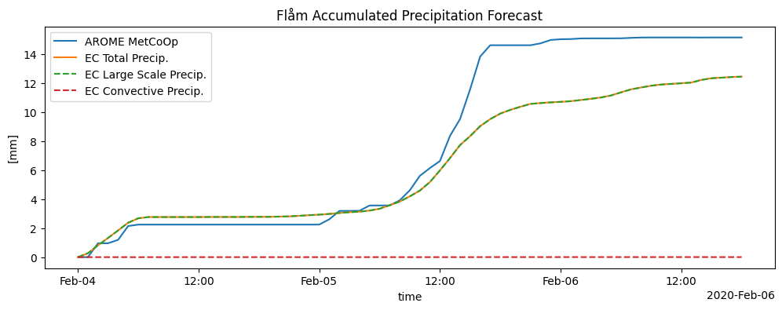

```python
plt.figure(figsize=(12,4))
pp_acc_point_arome = arome.precipitation_amount_acc.isel(height0=0,y=yloc,x=xloc)
pp_acc_point_ecifs = ecifs.sel(lat=lat0,lon=lon0,method='nearest')

pp_acc_point_arome.plot(x='time', linestyle='-', label='AROME MetCoOp')
(pp_acc_point_ecifs.TP*1000).plot(x='time', linestyle='-',label='EC Total Precip.')
(pp_acc_point_ecifs.LSP*1000).plot(x='time', linestyle='--',label='EC Large Scale Precip.')
((pp_acc_point_ecifs.TP-pp_acc_point_ecifs.LSP)*1000).plot(x='time',linestyle='--',label='EC Convective Precip.')

plt.legend()
plt.ylabel('[mm]')
plt.title("Flåm Accumulated Precipitation Forecast")
plt.show()
```